# EU Datathon

Luca B.

# Preamble

Loading required packages.

```r
library(data.table)
library(ggmap)
library(mapproj)
library(maptools)
library(rgdal)
library(raster)
library(openxlsx)
library(ggplot2)
library(dplyr)
library(stringr)
```

# Data Sources

Europe map has been downloaded via the R package available on CRAN. For more information please visit https://ropengov.github.io/eurostat/.

Here below a simple procedure to install (if not present) and load the package:

```r
if(require(eurostat) == FALSE){
  install.packages("eurostat")
  }else{
  library(eurostat)
  }
```

Once we download the data please remember to read the COPYRIGHT notice as indicated below.

```r
euromap <- get_eurostat_geospatial(output_class = "df",
                                   resolution = "20",
                                   nuts_level = "0",
                                   year = 2016)
```

```
COPYRIGHT NOTICE

When data downloaded from this page
is used in any printed or electronic publication,
in addition to any other provisions
applicable to the whole Eurostat website,
data source will have to be acknowledged
in the legend of the map and
in the introductory page of the publication
with the following copyright notice:

- EN: (C) EuroGeographics for the administrative boundaries
- FR: (C) EuroGeographics pour les limites administratives
- DE: (C) EuroGeographics bezuglich der Verwaltungsgrenzen

For publications in languages other than
English, French or German,
the translation of the copyright notice
in the language of the publication shall be used.

If you intend to use the data commercially,
please contact EuroGeographics for
information regarding their licence agreements.

No encoding supplied: defaulting to UTF-8.

# --------------------------
HEADS UP!!

Function now returns the data in 'sf'-class (simple features)
by default which is different
from previous behaviour's 'SpatialPolygonDataFrame'.

If you prefer either 'SpatialPolygonDataFrame' or
fortified 'data_frame' (for ggplot2::geom_polygon),
please specify it explicitly to 'output_class'-argument!

# --------------------------
```

Let’s review how the dataset looks like:

```r
head(euromap)
```

| long | lat | order | hole | piece | group | id | CNTR_CODE | NUTS_NAME | LEVL_CODE | FID | NUTS_ID | geo |
| --- | --- | --- | --- | --- | --- | --- | --- | --- | --- | --- | --- | --- |
| -7.03184 | 43.54447 | 1 | FALSE | 1 | 1.1 | 1 | ES | ESPAÑA | 0 | ES | ES | ES |
| -6.29214 | 43.56991 | 2 | FALSE | 1 | 1.1 | 1 | ES | ESPAÑA | 0 | ES | ES | ES |
| -5.84285 | 43.64158 | 3 | FALSE | 1 | 1.1 | 1 | ES | ESPAÑA | 0 | ES | ES | ES |
| -5.65981 | 43.55031 | 4 | FALSE | 1 | 1.1 | 1 | ES | ESPAÑA | 0 | ES | ES | ES |
| -5.38646 | 43.55023 | 5 | FALSE | 1 | 1.1 | 1 | ES | ESPAÑA | 0 | ES | ES | ES |
| -5.18044 | 43.47384 | 6 | FALSE | 1 | 1.1 | 1 | ES | ESPAÑA | 0 | ES | ES | ES |

And if now we decide to plot it:

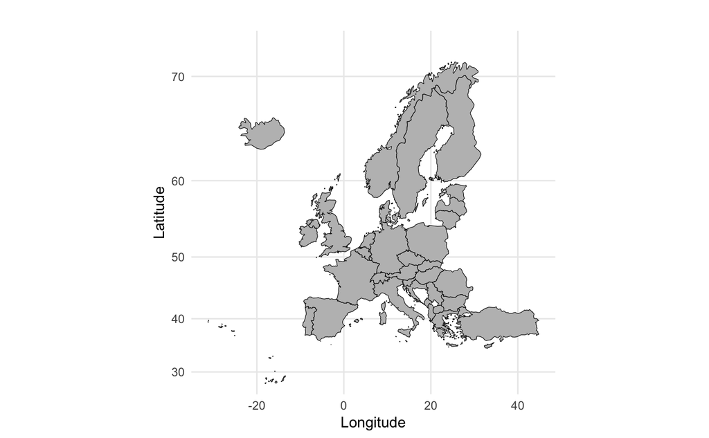

```r
ggplot() +
  geom_polygon(data = euromap %>% filter(lat > 27),
               aes(x = long, y = lat, group = group),
               color = 'black', size = .2, fill = "grey") +
  xlab("Longitude") +
  ylab("Latitude") +
  coord_map() +
  theme_minimal() +
  ggtitle("")
```

# Graphing external data sources on Europe map

The idea is to plot some indicators of CO concentrations for Europe, as provided in the **AirPollution** folder. CO concentration readings per country are stored in seperate csv files, one per each country. Records of CO concentrations range from the start to the end of year 2017. Therefore data at hand are time series. For the explorative analysis conducted in this quick study we would like to summarize the information on CO concentration for the overall year per each country via a single paramter, may it be concentrations averaged on the overall year or something similar. We therefore do not consider hereafter an analysis taking into account time-dependencies, seasonalities of the CO concentration etc. (It may be interesting to do so though).

We now perform a operation in order to enrich the euromap dataset with the necessary codenames for a future link to the AirPollution data.

```r
dic <- read.xlsx("dic.xlsx")
euromap <- left_join(euromap, dic %>% dplyr::select(Name, English_Name, Code_Name), by = c("NUTS_NAME" = "Name"))
```

Let’s review the dataset:

```r
head(euromap)
```

| long | lat | order | hole | piece | group | id | CNTR_CODE | NUTS_NAME | LEVL_CODE | FID | NUTS_ID | geo | English_Name | Code_Name |
| --- | --- | --- | --- | --- | --- | --- | --- | --- | --- | --- | --- | --- | --- | --- |
| -7.03184 | 43.54447 | 1 | FALSE | 1 | 1.1 | 1 | ES | ESPAÑA | 0 | ES | ES | ES | Spain | ES |
| -6.29214 | 43.56991 | 2 | FALSE | 1 | 1.1 | 1 | ES | ESPAÑA | 0 | ES | ES | ES | Spain | ES |
| -5.84285 | 43.64158 | 3 | FALSE | 1 | 1.1 | 1 | ES | ESPAÑA | 0 | ES | ES | ES | Spain | ES |
| -5.65981 | 43.55031 | 4 | FALSE | 1 | 1.1 | 1 | ES | ESPAÑA | 0 | ES | ES | ES | Spain | ES |
| -5.38646 | 43.55023 | 5 | FALSE | 1 | 1.1 | 1 | ES | ESPAÑA | 0 | ES | ES | ES | Spain | ES |
| -5.18044 | 43.47384 | 6 | FALSE | 1 | 1.1 | 1 | ES | ESPAÑA | 0 | ES | ES | ES | Spain | ES |

Now we parse all the AirPollution files for which we have a corresponding region on the map. For example we have data on CO concentrations in Andorra but we do not have a key for Andorra in the geospatial dataset euromap. This means we cannot map the values of CO concentrations on the previous graph since we would need the latitudes and longitudes corresponding to Andorra, shortly speaking.

```r
index_countries <- list.files("AirPollution/") %>% stringr::str_extract(.,pattern = "[A-z]{2}")
files_2_be_parsed <- list.files("AirPollution/")[index_countries  %in% unique(euromap$geo)]
index_countries <- index_countries[index_countries %in% unique(euromap$geo)]
```

# Compute CO concentration per country in 2017, yearly averaged.

```r
df_airpoll <- data.frame()
for (i in seq_along(files_2_be_parsed)){

  df <- read.csv(paste0("AirPollution/",files_2_be_parsed[i]), fileEncoding = "UTF-16")
  df$DatetimeBegin <- as.Date(df$DatetimeBegin)
  df$DatetimeEnd <- as.Date(df$DatetimeEnd)
  df <- df %>% filter(AirPollutant == "CO") %>%
    mutate(Year = year(DatetimeBegin), Month = month(DatetimeBegin)) %>%
    dplyr::select(Year, Month, Concentration, UnitOfMeasurement) %>%
    group_by(Year) %>%
    summarise(avg_CO_concentration_year= mean(Concentration)) %>%
    ungroup() %>%
    mutate(geo = index_countries[i])

  df_airpoll <- bind_rows(df_airpoll, df)

}
```

```r
euromap_1 <- left_join(euromap, df_airpoll, by = "geo")
```

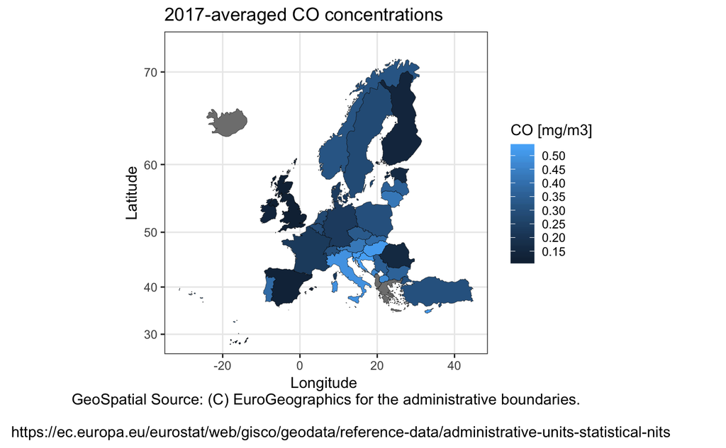

```r
europe_map_1 <- ggplot() +
  geom_polygon(data = euromap_1 %>% filter(lat > 27),
               aes(x = long, y = lat, group = group, fill = avg_CO_concentration_year),
               color = 'black', size = .1) +
  xlab("Longitude \n GeoSpatial Source: (C) EuroGeographics for the administrative boundaries. \n
       https://ec.europa.eu/eurostat/web/gisco/geodata/reference-data/administrative-units-statistical-nits") +
  ylab("Latitude") +
  coord_map() +
  theme_bw() +
  scale_fill_continuous(name = "CO [mg/m3]",
                        breaks = seq(0,0.5,by = 0.05)) +
  ggtitle("2017-averaged CO concentrations")
europe_map_1
```

# Compute CO concentrations per country in 2017, averaged by season.

We use 3-months windows as proxies for seasons. Winter being January-March, Spring April-June etc.

```r
df_airpoll <- data.frame()
for (i in seq_along(files_2_be_parsed)){

  df <- read.csv(paste0("AirPollution/",files_2_be_parsed[i]), fileEncoding = "UTF-16")
  df$DatetimeBegin <- as.Date(df$DatetimeBegin)
  df$DatetimeEnd <- as.Date(df$DatetimeEnd)
  df <- df %>% filter(AirPollutant == "CO") %>%
    mutate(Year = year(DatetimeBegin), Month = month(DatetimeBegin)) %>%
    rowwise() %>%
    mutate(Season = c("winter","spring","summer","autumn")[first(which(Month <= c(3,6,9,12)))])
  df <- df %>%
    dplyr::select(Year, Month, Concentration, UnitOfMeasurement, Season) %>%
    group_by(Year, Season) %>%
    summarise(avg_season_CO_concentration= mean(Concentration)) %>%
    ungroup() %>%
    mutate(geo = index_countries[i])

  df_airpoll <- bind_rows(df_airpoll, df)

}
```

Let’s enrich the dataset:

```r
euromap_2 <- left_join(euromap, df_airpoll, by = "geo")
```

Winter:

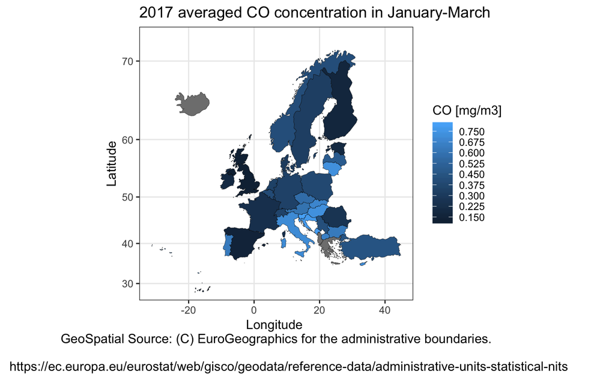

```r
europe_map_winter <- ggplot() +
  geom_polygon(data = euromap_2 %>% filter(lat > 27 & Season %in% c("winter",NA)),
               aes(x = long, y = lat, group = group, fill = avg_season_CO_concentration),
               color = 'black', size = .1) +
  xlab("Longitude \n GeoSpatial Source: (C) EuroGeographics for the administrative boundaries. \n
       https://ec.europa.eu/eurostat/web/gisco/geodata/reference-data/administrative-units-statistical-nits") +
  ylab("Latitude") +
  coord_map() +
  theme_bw() +
  scale_fill_continuous(name = "CO [mg/m3]",
                        breaks = seq(0,0.8,by = 0.075)) +
  ggtitle("2017 averaged CO concentration in January-March")
europe_map_winter
```

Summer:

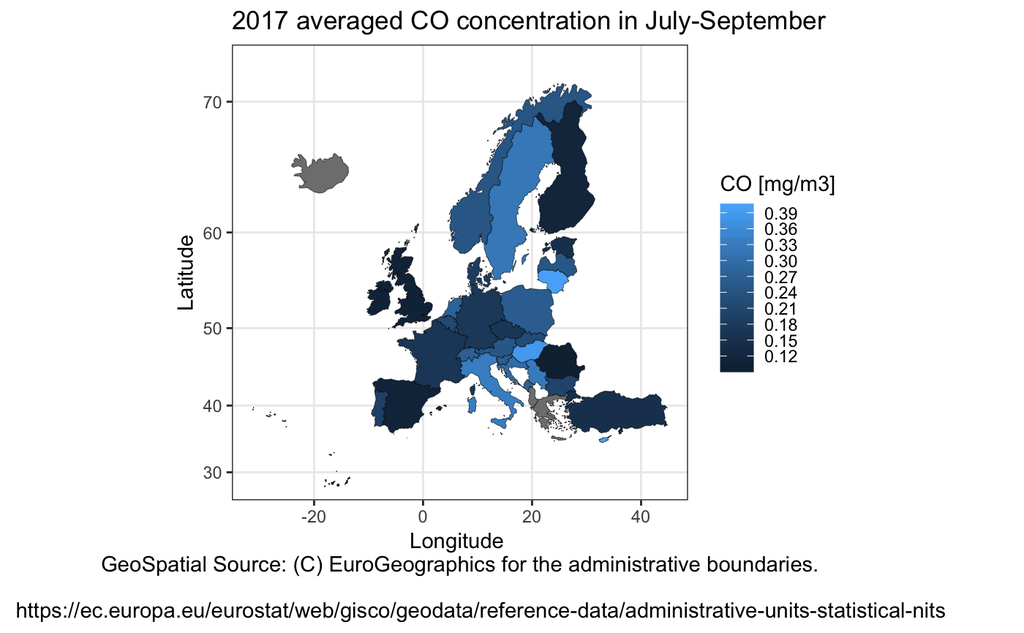

```r
europe_map_summer <- ggplot() +
  geom_polygon(data = euromap_2 %>% filter(lat > 27 & Season %in% c("summer",NA)),
               aes(x = long, y = lat, group = group, fill = avg_season_CO_concentration),
               color = 'black', size = .1) +
  xlab("Longitude \n GeoSpatial Source: (C) EuroGeographics for the administrative boundaries. \n
       https://ec.europa.eu/eurostat/web/gisco/geodata/reference-data/administrative-units-statistical-nits") +
  ylab("Latitude") +
  coord_map() +
  theme_bw() +
  scale_fill_continuous(name = "CO [mg/m3]",
                        breaks = seq(0,0.4,by = 0.030)) +
  ggtitle("2017 averaged CO concentration in July-September")
europe_map_summer
```

NB SOMETHING IS PRETTY CURIOUS ABOUT ALBANIA. Super high concentrations also in summer (relative to the other countries) maybe it requires some investigation. For the time being the analysis excludes Albanie from the AirPollution folder. In order to so we have changed the name of the csv file from AL_10_34828_2017_timeseries.csv to EXCLUDED_AL_10_34828_2017_timeseries.csv. In such case the first two letters of the file EX do not match any kind of country so automatically the data from Albanie is not parsed.